# Lake Bilancio

Rodion Sharafiev

08 01 2021

```r
setwd("C:\\Users\\rsharafiev\\DS\\exam\\Acea-Smart-Water-Analytics")
library(lubridate)
library(data.table)
library(aTSA)
library(vars)
#library(tseries)
#library(urca)
#library(TSstudio)
#library(forecast)
#library(imputeTS)
df <- read.csv("Lake_Bilancino.csv")
```

Our features are Rainfall_S_Piero, Rainfall_Mangona, Rainfall_S_Agata, Rainfall_Cavallina, Rainfall_Le_Croci, Temperature_Le_Croci. Output Lake_Level and Flow_Rate.

```r
df$п.їDate = strptime(df$п.їDate, "%d/%m/%Y")
df$Date <- ymd(df$п.їDate)
```

#Some checks for data

Is date ordered and there are no any missing days?

```r
df <- df[order(df$Date), ]
df['Interval']=df$Date - shift(df$Date, n=1, fill=NA, type="lag")
days <- df$Interval

for(i in days)
{

  if(isTRUE(i > 1) || is.null(i))
  {
    print(i)
  }

}
df<-df[,2:10]
```

Yes. Also we will save only our date.

Let’s see sum summaries.

```r
summary(df)
```

```
##  Rainfall_S_Piero Rainfall_Mangona  Rainfall_S_Agata Rainfall_Cavallina
##  Min.   : 0.000   Min.   :  0.000   Min.   :  0.00   Min.   :  0.000
##  1st Qu.: 0.000   1st Qu.:  0.000   1st Qu.:  0.00   1st Qu.:  0.000
##  Median : 0.000   Median :  0.000   Median :  0.00   Median :  0.000
##  Mean   : 2.471   Mean   :  3.341   Mean   :  2.67   Mean   :  2.675
##  3rd Qu.: 0.800   3rd Qu.:  1.400   3rd Qu.:  1.20   3rd Qu.:  0.600
##  Max.   :80.600   Max.   :110.000   Max.   :120.20   Max.   :113.600
##  NA's   :577      NA's   :577       NA's   :577      NA's   :577
##  Rainfall_Le_Croci Temperature_Le_Croci   Lake_Level      Flow_Rate
##  Min.   : 0.00     Min.   :-5.35        Min.   :243.5   Min.   : 0.310
##  1st Qu.: 0.00     1st Qu.: 9.00        1st Qu.:248.0   1st Qu.: 0.600
##  Median : 0.00     Median :14.50        Median :250.2   Median : 1.500
##  Mean   : 3.13     Mean   :14.53        Mean   :249.6   Mean   : 2.761
##  3rd Qu.: 1.20     3rd Qu.:20.10        3rd Qu.:251.4   3rd Qu.: 3.000
##  Max.   :88.40     Max.   :34.00        Max.   :252.8   Max.   :74.650
##  NA's   :577       NA's   :578                          NA's   :21
##       Date
##  Min.   :2002-06-03
##  1st Qu.:2006-12-09
##  Median :2011-06-17
##  Mean   :2011-06-17
##  3rd Qu.:2015-12-23
##  Max.   :2020-06-30
##
```

```r
summary(df[1:578,])
```

```
##  Rainfall_S_Piero Rainfall_Mangona Rainfall_S_Agata Rainfall_Cavallina
##  Min.   :0        Min.   :0        Min.   :0.4      Min.   :0
##  1st Qu.:0        1st Qu.:0        1st Qu.:0.4      1st Qu.:0
##  Median :0        Median :0        Median :0.4      Median :0
##  Mean   :0        Mean   :0        Mean   :0.4      Mean   :0
##  3rd Qu.:0        3rd Qu.:0        3rd Qu.:0.4      3rd Qu.:0
##  Max.   :0        Max.   :0        Max.   :0.4      Max.   :0
##  NA's   :577      NA's   :577      NA's   :577      NA's   :577
##  Rainfall_Le_Croci Temperature_Le_Croci   Lake_Level      Flow_Rate
##  Min.   :0         Min.   : NA          Min.   :245.0   Min.   : 0.310
##  1st Qu.:0         1st Qu.: NA          1st Qu.:248.2   1st Qu.: 0.600
##  Median :0         Median : NA          Median :249.7   Median : 1.700
##  Mean   :0         Mean   :NaN          Mean   :249.7   Mean   : 2.575
##  3rd Qu.:0         3rd Qu.: NA          3rd Qu.:251.6   3rd Qu.: 3.000
##  Max.   :0         Max.   : NA          Max.   :252.2   Max.   :40.000
##  NA's   :577       NA's   :578                          NA's   :21
##       Date
##  Min.   :2002-06-03
##  1st Qu.:2002-10-25
##  Median :2003-03-18
##  Mean   :2003-03-18
##  3rd Qu.:2003-08-09
##  Max.   :2004-01-01
##
```

We see that first 578 records have are useless for us (no data about rainfall, temperature and missing values for flow rate). So we don’t need them any more.

```r
df <- df[579:6603,]
summary(df)
```

```
##  Rainfall_S_Piero Rainfall_Mangona  Rainfall_S_Agata Rainfall_Cavallina
##  Min.   : 0.000   Min.   :  0.000   Min.   :  0.00   Min.   :  0.000
##  1st Qu.: 0.000   1st Qu.:  0.000   1st Qu.:  0.00   1st Qu.:  0.000
##  Median : 0.000   Median :  0.000   Median :  0.00   Median :  0.000
##  Mean   : 2.472   Mean   :  3.341   Mean   :  2.67   Mean   :  2.675
##  3rd Qu.: 0.800   3rd Qu.:  1.400   3rd Qu.:  1.20   3rd Qu.:  0.600
##  Max.   :80.600   Max.   :110.000   Max.   :120.20   Max.   :113.600
##  Rainfall_Le_Croci Temperature_Le_Croci   Lake_Level      Flow_Rate
##  Min.   : 0.00     Min.   :-5.35        Min.   :243.5   Min.   : 0.450
##  1st Qu.: 0.00     1st Qu.: 9.00        1st Qu.:247.9   1st Qu.: 0.600
##  Median : 0.00     Median :14.50        Median :250.2   Median : 1.500
##  Mean   : 3.13     Mean   :14.53        Mean   :249.6   Mean   : 2.778
##  3rd Qu.: 1.20     3rd Qu.:20.10        3rd Qu.:251.4   3rd Qu.: 3.000
##  Max.   :88.40     Max.   :34.00        Max.   :252.8   Max.   :74.650
##       Date
##  Min.   :2004-01-02
##  1st Qu.:2008-02-16
##  Median :2012-04-01
##  Mean   :2012-04-01
##  3rd Qu.:2016-05-16
##  Max.   :2020-06-30
```

Let’s check stationary and make some transformations.

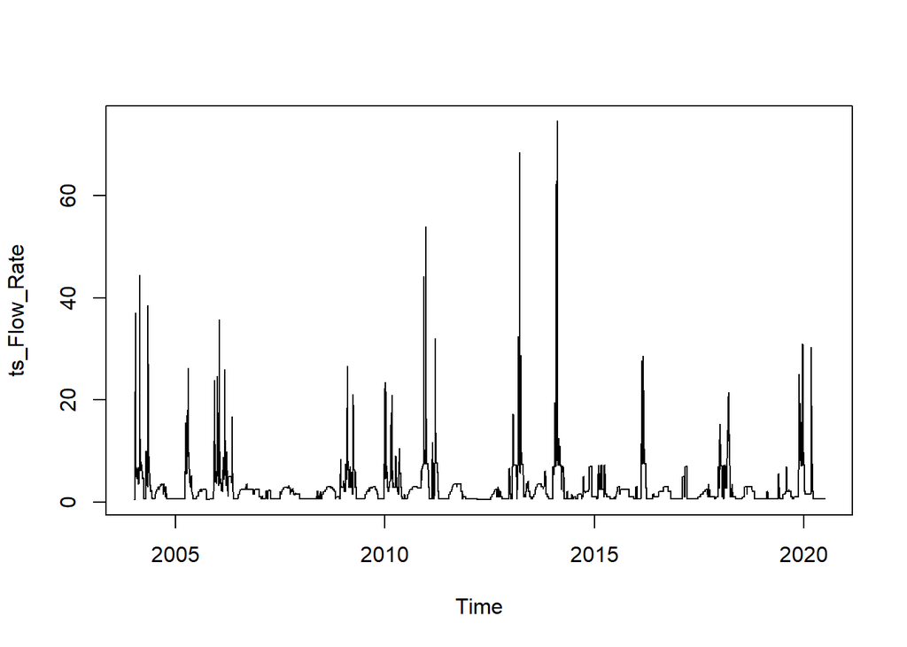

```r
ts_Flow_Rate <- ts(df$Flow_Rate, start=c(2004,2), frequency = 365.25)
plot(ts_Flow_Rate)
```

```r
adf.test(ts_Flow_Rate)
```

```
## Augmented Dickey-Fuller Test
## alternative: stationary
##
## Type 1: no drift no trend
##       lag    ADF p.value
##  [1,]   0 -18.16    0.01
##  [2,]   1 -19.99    0.01
##  [3,]   2 -15.58    0.01
##  [4,]   3 -14.36    0.01
##  [5,]   4 -12.90    0.01
##  [6,]   5 -12.10    0.01
##  [7,]   6 -11.14    0.01
##  [8,]   7 -10.28    0.01
##  [9,]   8  -9.60    0.01
## [10,]   9  -8.52    0.01
```

[output cut: 26 more lines]

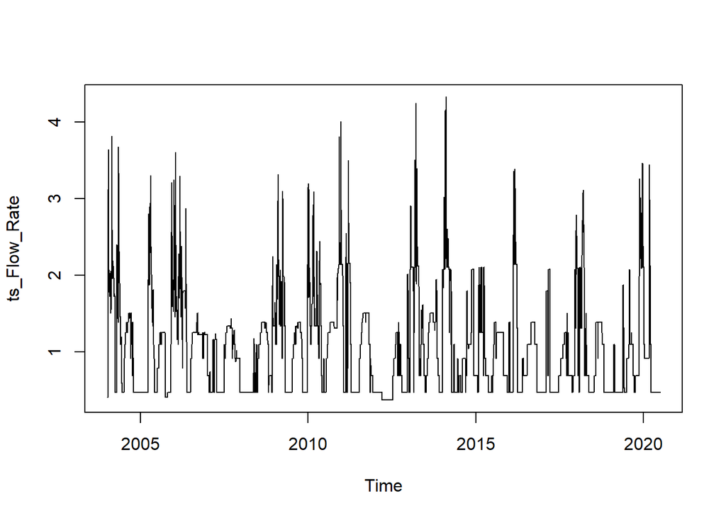

```r
ts_Flow_Rate <- log(ts(df$Flow_Rate+1, start=c(2004,2), frequency = 365.25))
plot(ts_Flow_Rate)
```

```r
adf.test(ts_Flow_Rate)
```

```
## Augmented Dickey-Fuller Test
## alternative: stationary
##
## Type 1: no drift no trend
##       lag   ADF p.value
##  [1,]   0 -5.41    0.01
##  [2,]   1 -6.23    0.01
##  [3,]   2 -5.65    0.01
##  [4,]   3 -5.40    0.01
##  [5,]   4 -5.19    0.01
##  [6,]   5 -5.18    0.01
##  [7,]   6 -5.06    0.01
##  [8,]   7 -4.93    0.01
##  [9,]   8 -4.82    0.01
## [10,]   9 -4.67    0.01
```

[output cut: 26 more lines]

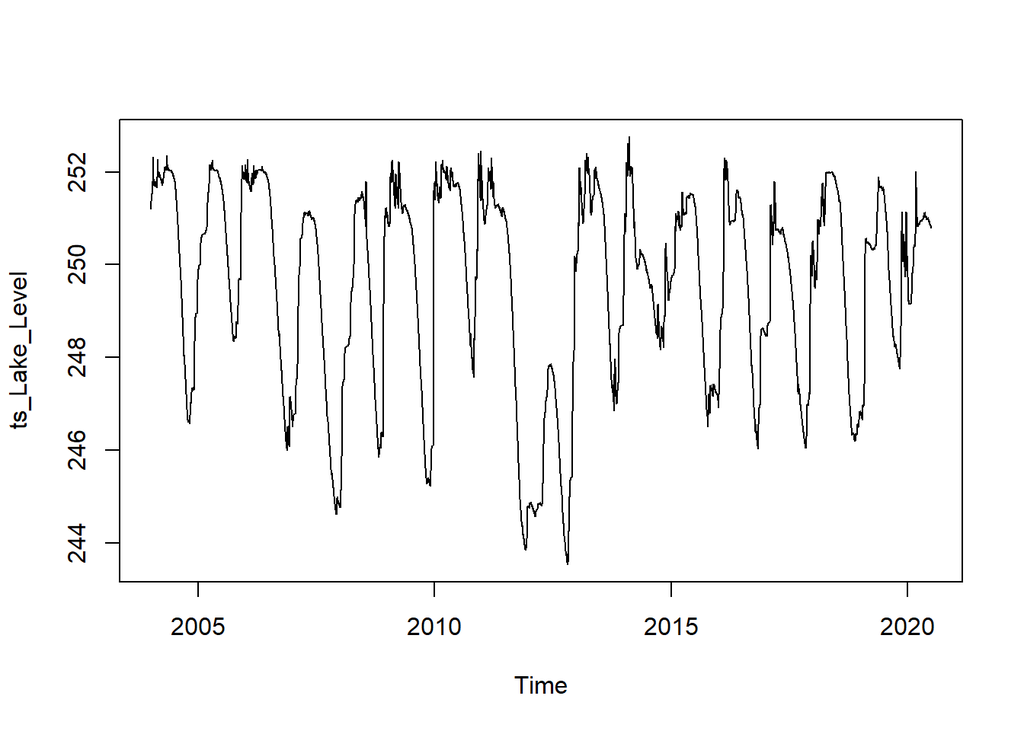

```r
ts_Lake_Level <- ts(df$Lake_Level, start=c(2004,2), frequency = 365.25)
plot(ts_Lake_Level)
```

```r
adf.test(ts_Lake_Level)
```

```
## Augmented Dickey-Fuller Test
## alternative: stationary
##
## Type 1: no drift no trend
##       lag     ADF p.value
##  [1,]   0 -0.0674   0.625
##  [2,]   1 -0.0688   0.624
##  [3,]   2 -0.0747   0.622
##  [4,]   3 -0.0730   0.623
##  [5,]   4 -0.0783   0.621
##  [6,]   5 -0.0765   0.622
##  [7,]   6 -0.0782   0.622
##  [8,]   7 -0.0825   0.620
##  [9,]   8 -0.0840   0.620
## [10,]   9 -0.0829   0.620
```

[output cut: 26 more lines]

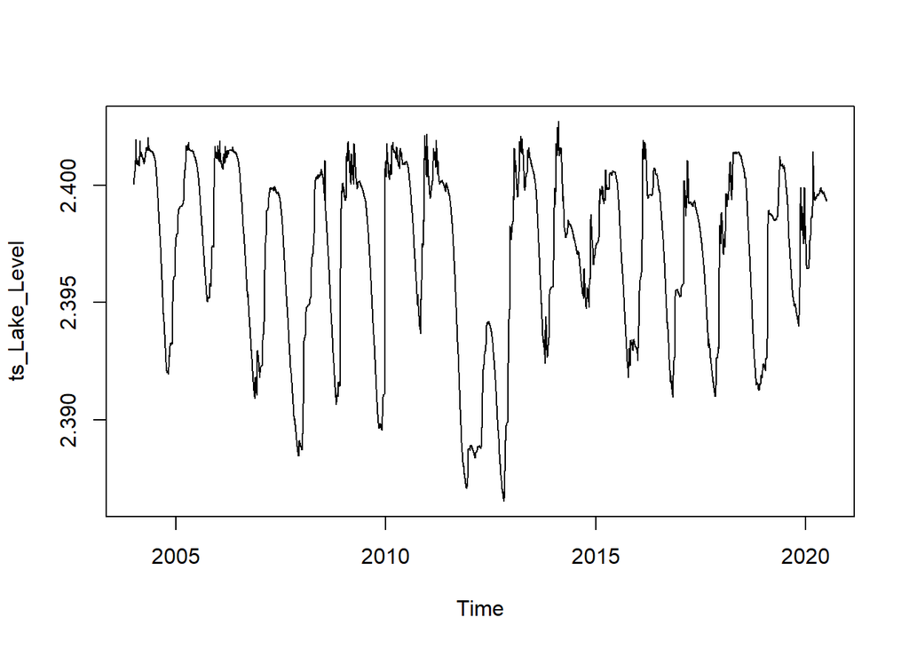

```r
ts_Lake_Level<-log10(ts_Lake_Level)
plot(ts_Lake_Level)
```

```r
adf.test(ts_Lake_Level)
```

```
## Augmented Dickey-Fuller Test
## alternative: stationary
##
## Type 1: no drift no trend
##       lag     ADF p.value
##  [1,]   0 -0.0536   0.629
##  [2,]   1 -0.0469   0.631
##  [3,]   2 -0.0506   0.629
##  [4,]   3 -0.0480   0.630
##  [5,]   4 -0.0523   0.629
##  [6,]   5 -0.0499   0.630
##  [7,]   6 -0.0508   0.629
##  [8,]   7 -0.0544   0.628
##  [9,]   8 -0.0553   0.628
## [10,]   9 -0.0540   0.628
```

[output cut: 26 more lines]

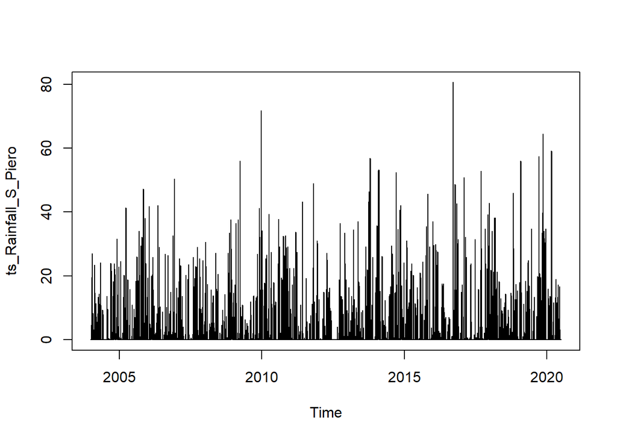

```r
ts_Rainfall_S_Piero <- ts(df$Rainfall_S_Piero, start=c(2004,2), frequency = 365.25)
plot(ts_Rainfall_S_Piero)
```

```r
result = adf.test(ts_Rainfall_S_Piero)
```

```
## Augmented Dickey-Fuller Test
## alternative: stationary
##
## Type 1: no drift no trend
##       lag   ADF p.value
##  [1,]   0 -54.6    0.01
##  [2,]   1 -39.9    0.01
##  [3,]   2 -32.9    0.01
##  [4,]   3 -28.1    0.01
##  [5,]   4 -24.8    0.01
##  [6,]   5 -22.4    0.01
##  [7,]   6 -20.6    0.01
##  [8,]   7 -18.9    0.01
##  [9,]   8 -16.7    0.01
## [10,]   9 -15.7    0.01
```

[output cut: 26 more lines]

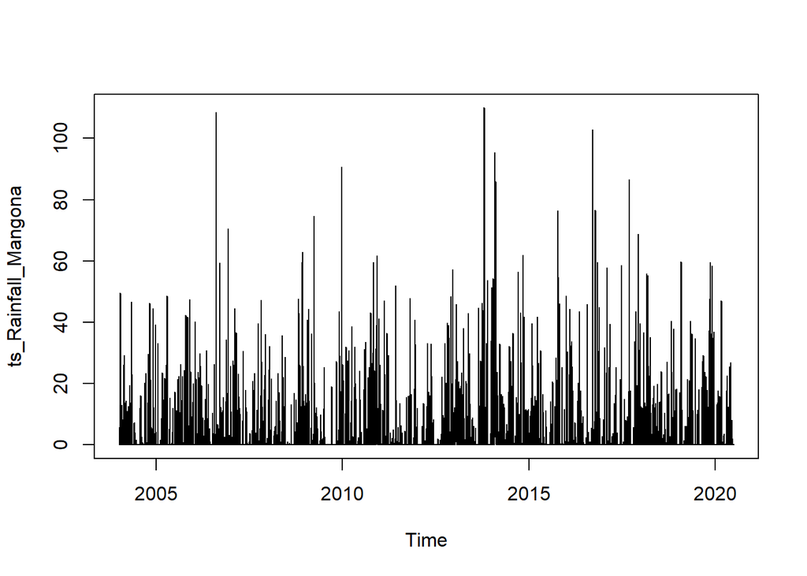

```r
ts_Rainfall_Mangona <- ts(df$Rainfall_Mangona, start=c(2004,2), frequency = 365.25)
plot(ts_Rainfall_Mangona)
```

```r
result = adf.test(ts_Rainfall_Mangona)
```

```
## Augmented Dickey-Fuller Test
## alternative: stationary
##
## Type 1: no drift no trend
##       lag   ADF p.value
##  [1,]   0 -53.1    0.01
##  [2,]   1 -39.4    0.01
##  [3,]   2 -32.2    0.01
##  [4,]   3 -27.4    0.01
##  [5,]   4 -24.4    0.01
##  [6,]   5 -21.9    0.01
##  [7,]   6 -20.1    0.01
##  [8,]   7 -18.8    0.01
##  [9,]   8 -17.1    0.01
## [10,]   9 -15.8    0.01
```

[output cut: 26 more lines]

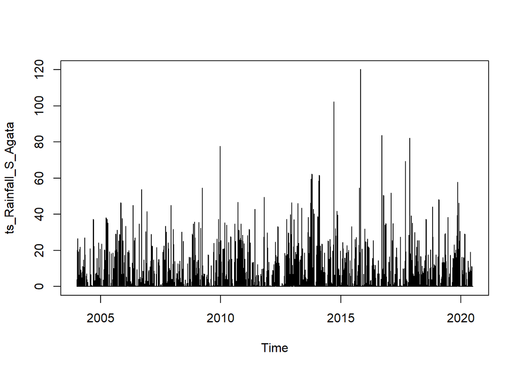

```r
ts_Rainfall_S_Agata <- ts(df$Rainfall_S_Agata, start=c(2004,2), frequency = 365.25)
plot(ts_Rainfall_S_Agata)
```

```r
result = adf.test(ts_Rainfall_S_Agata)
```

```
## Augmented Dickey-Fuller Test
## alternative: stationary
##
## Type 1: no drift no trend
##       lag   ADF p.value
##  [1,]   0 -56.2    0.01
##  [2,]   1 -41.4    0.01
##  [3,]   2 -33.2    0.01
##  [4,]   3 -28.6    0.01
##  [5,]   4 -25.0    0.01
##  [6,]   5 -22.2    0.01
##  [7,]   6 -20.3    0.01
##  [8,]   7 -18.6    0.01
##  [9,]   8 -16.8    0.01
## [10,]   9 -15.5    0.01
```

[output cut: 26 more lines]

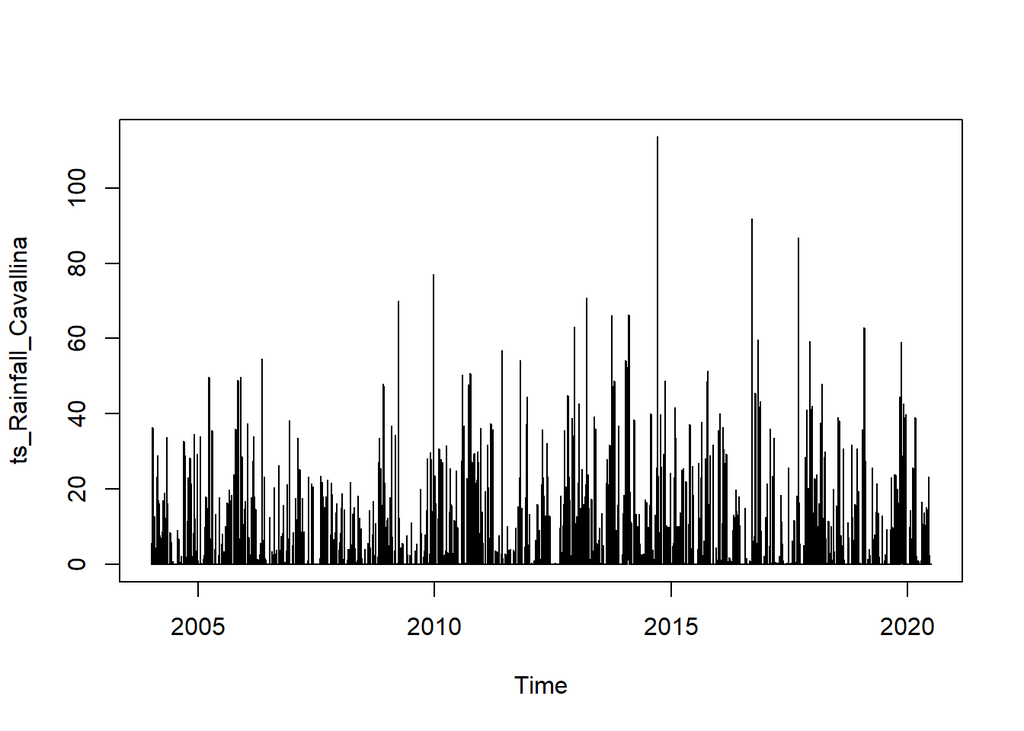

```r
ts_Rainfall_Cavallina <- ts(df$Rainfall_Cavallina, start=c(2004,2), frequency = 365.25)
plot(ts_Rainfall_Cavallina)
```

```r
result = adf.test(ts_Rainfall_Cavallina)
```

```
## Augmented Dickey-Fuller Test
## alternative: stationary
##
## Type 1: no drift no trend
##       lag   ADF p.value
##  [1,]   0 -56.7    0.01
##  [2,]   1 -41.0    0.01
##  [3,]   2 -33.4    0.01
##  [4,]   3 -28.4    0.01
##  [5,]   4 -25.3    0.01
##  [6,]   5 -22.6    0.01
##  [7,]   6 -20.8    0.01
##  [8,]   7 -19.1    0.01
##  [9,]   8 -17.0    0.01
## [10,]   9 -15.9    0.01
```

[output cut: 26 more lines]

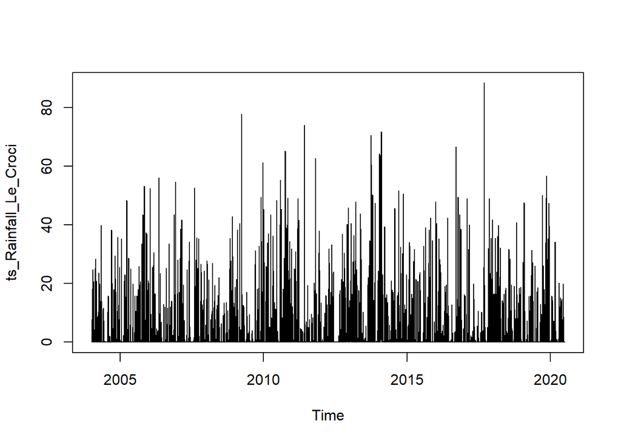

```r
ts_Rainfall_Le_Croci <- ts(df$Rainfall_Le_Croci, start=c(2004,2), frequency = 365.25)
plot(ts_Rainfall_Le_Croci)
```

```r
result = adf.test(ts_Rainfall_Le_Croci)
```

```
## Augmented Dickey-Fuller Test
## alternative: stationary
##
## Type 1: no drift no trend
##       lag   ADF p.value
##  [1,]   0 -55.1    0.01
##  [2,]   1 -39.8    0.01
##  [3,]   2 -32.2    0.01
##  [4,]   3 -27.6    0.01
##  [5,]   4 -24.4    0.01
##  [6,]   5 -21.6    0.01
##  [7,]   6 -19.6    0.01
##  [8,]   7 -18.2    0.01
##  [9,]   8 -16.4    0.01
## [10,]   9 -15.3    0.01
```

[output cut: 26 more lines]

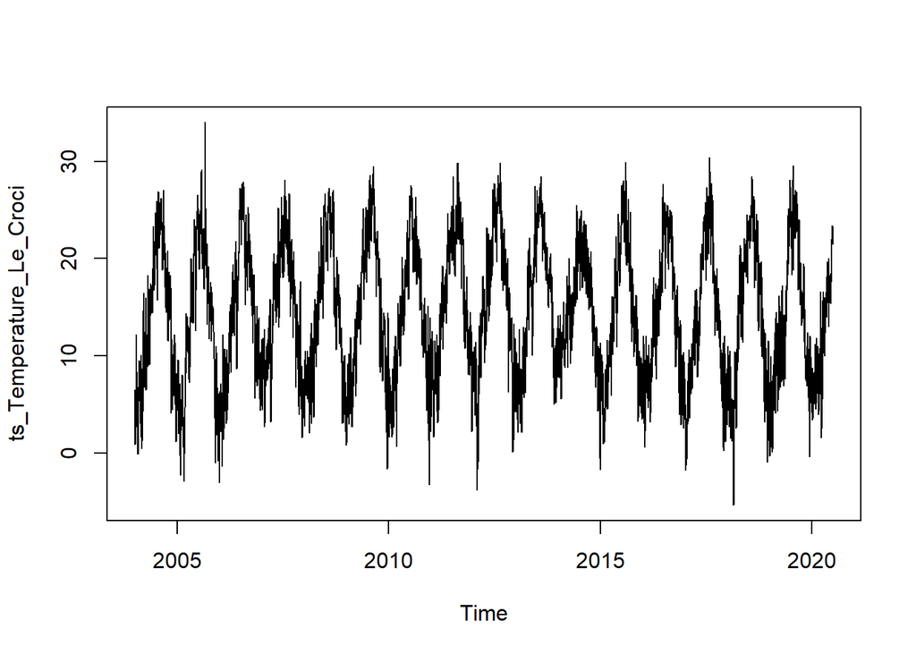

```r
ts_Temperature_Le_Croci <- ts(df$Temperature_Le_Croci, start=c(2004,2), frequency = 365.25)
plot(ts_Temperature_Le_Croci)
```

```r
result = adf.test(ts_Temperature_Le_Croci)
```

```
## Augmented Dickey-Fuller Test
## alternative: stationary
##
## Type 1: no drift no trend
##       lag   ADF p.value
##  [1,]   0 -4.58  0.0100
##  [2,]   1 -4.31  0.0100
##  [3,]   2 -3.81  0.0100
##  [4,]   3 -3.32  0.0100
##  [5,]   4 -3.04  0.0100
##  [6,]   5 -2.75  0.0100
##  [7,]   6 -2.57  0.0104
##  [8,]   7 -2.41  0.0173
##  [9,]   8 -2.27  0.0234
## [10,]   9 -2.18  0.0295
```

[output cut: 26 more lines]

Now we need to determine p.

```r
y <- cbind(ts_Flow_Rate, ts_Lake_Level)
colnames(y)<-cbind("Flow_Rate", "Lake_Level")

x <- cbind(ts_Rainfall_Cavallina, ts_Rainfall_Le_Croci, ts_Rainfall_Mangona, ts_Rainfall_S_Agata, ts_Rainfall_S_Piero, ts_Temperature_Le_Croci)
colnames(x)<-cbind("Rainfall_Cavallina", "Rainfall_Le_Croci", "Rainfall_Mangona", "Rainfall_S_Agata", "Rainfall_S_Piero", "Temperature_Le_Croci")
lagselect <- VARselect(y=y, type = "const", exogen = x)
lagselect$selection
```

```
## AIC(n)  HQ(n)  SC(n) FPE(n)
##      5      3      3      5
```

We will use AIC’s p=5. Prepare some train and test data.

```r
border <- length(y[,1])-2*365
train_y <- y[1:border,]
train_x <- x[1:border,]
test_y <- y[(border+1):6025,]
test_x <- x[(border+1):6025,]
```

Create model with p=5.

```r
Model1 <- VAR(train_y, p = 5, type = "const",  exogen = train_x)
summary(Model1)
```

```
##
## VAR Estimation Results:
## =========================
## Endogenous variables: Flow_Rate, Lake_Level
## Deterministic variables: const
## Sample size: 5290
## Log Likelihood: 41276.73
## Roots of the characteristic polynomial:
## 0.9978 0.9561 0.6239 0.5088 0.5088 0.3794 0.3794 0.3225 0.3075 0.3075
## Call:
## VAR(y = train_y, p = 5, type = "const", exogen = train_x)
##
##
## Estimation results for equation Flow_Rate:
## ==========================================
## Flow_Rate = Flow_Rate.l1 + Lake_Level.l1 + Flow_Rate.l2 + Lake_Level.l2 + Flow_Rate.l3 + Lake_Level.l3 + Flow_Rate.l4 + Lake_Level.l4 + Flow_Rate.l5 + Lake_Level.l5 + const + Rainfall_Cavallina + Rainfall_Le_Croci + Rainfall_Mangona + Rainfall_S_Agata + Rainfall_S_Piero + Temperature_Le_Croci
##
##                        Estimate Std. Error t value Pr(>|t|)
## Flow_Rate.l1          1.067e+00  1.396e-02  76.447  < 2e-16 ***
## Lake_Level.l1         7.184e+01  1.546e+01   4.647 3.45e-06 ***
## Flow_Rate.l2         -2.172e-01  2.048e-02 -10.608  < 2e-16 ***
## Lake_Level.l2        -3.173e+01  2.565e+01  -1.237 0.216124
## Flow_Rate.l3          6.133e-02  2.075e-02   2.956 0.003133 **
## Lake_Level.l3        -1.994e+01  2.578e+01  -0.774 0.439176
## Flow_Rate.l4          8.526e-03  2.064e-02   0.413 0.679549
## Lake_Level.l4         1.048e+01  2.545e+01   0.412 0.680416
## Flow_Rate.l5          3.951e-02  1.417e-02   2.788 0.005329 **
## Lake_Level.l5        -2.794e+01  1.538e+01  -1.816 0.069375 .
## const                -6.460e+00  1.519e+00  -4.252 2.16e-05 ***
## Rainfall_Cavallina    4.643e-03  9.453e-04   4.912 9.30e-07 ***
## Rainfall_Le_Croci     2.275e-03  8.464e-04   2.687 0.007227 **
## Rainfall_Mangona      2.159e-03  5.866e-04   3.680 0.000236 ***
## Rainfall_S_Agata     -1.872e-03  8.226e-04  -2.276 0.022910 *
## Rainfall_S_Piero     -3.437e-03  1.043e-03  -3.295 0.000992 ***
## Temperature_Le_Croci  1.035e-03  3.681e-04   2.813 0.004925 **
## ---
## Signif. codes:  0 '***' 0.001 '**' 0.01 '*' 0.05 '.' 0.1 ' ' 1
##
##
## Residual standard error: 0.1666 on 5273 degrees of freedom
```

[output cut: 30 more lines]

```
## Residual standard error: 0.0001478 on 5273 degrees of freedom
## Multiple R-Squared: 0.9986,  Adjusted R-squared: 0.9986
## F-statistic: 2.322e+05 on 16 and 5273 DF,  p-value: < 2.2e-16
##
##
##
## Covariance matrix of residuals:
##            Flow_Rate Lake_Level
## Flow_Rate  2.776e-02  5.490e-06
## Lake_Level 5.490e-06  2.183e-08
##
## Correlation matrix of residuals:
##            Flow_Rate Lake_Level
## Flow_Rate      1.000      0.223
## Lake_Level     0.223      1.000
```

P-value, R-squared and F-static are good.

Let’s try to predict values.

```r
pred_y <- predict(Model1, n.ahead =2*365, dumvar=test_x, ci=0.95)
```

Visualize test data and prediction.

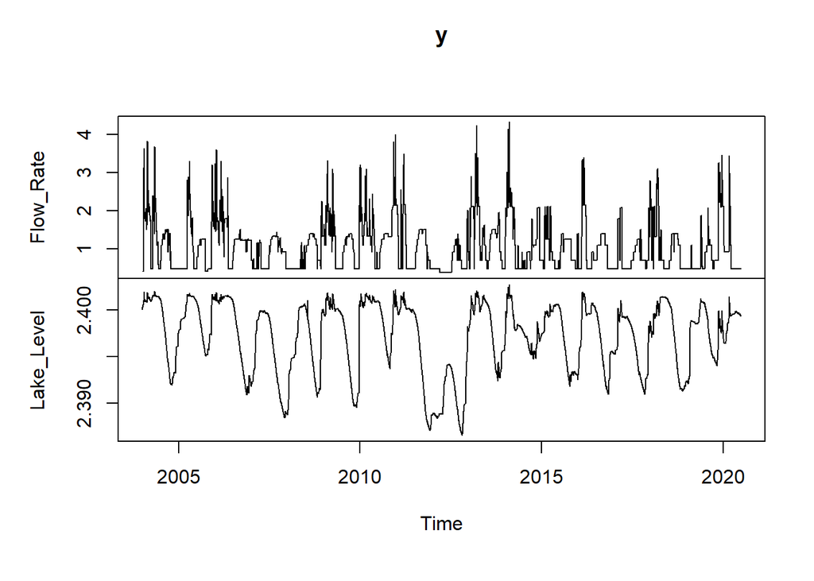

```r
plot(y)
```

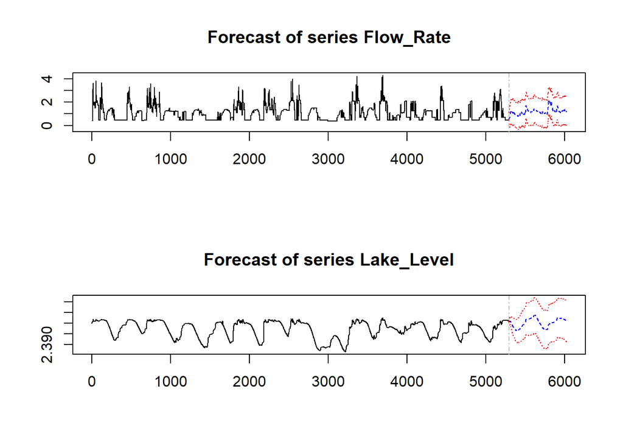

```r
plot(pred_y)
```

```r
cross_val <- function(x, y, p) {
  max <- length(y[,1])
  border <- max-2*365
  pred_length <- 3
  errors_Flow=0
  errors_Level=0
  measures = 0
  while (border+pred_length <= max) {
    train_y <- y[1:border,]
    train_x <- x[1:border,]
    test_y <- y[(border+1):(border+pred_length),]
    test_x <- x[(border+1):(border+pred_length),]
    test_Model <- VAR(train_y, p = p, type = "const",  exogen = train_x)
    pred_y <- predict(test_Model, n.ahead = pred_length, dumvar=test_x, ci=0.95)
    check<-pred_y$fcst$Flow_Rate
    errors_Flow <- sum((check[,1]-test_y[,1])^2)+errors_Flow
    check<-pred_y$fcst$Lake_Level
    errors_Level <- sum((check[,1]-test_y[,2])^2)+errors_Level
    measures=measures + 3
    border=border+pred_length
  }
  RMSE_Flow = sqrt(errors_Flow/measures)
  RMSE_Level = sqrt(errors_Level/measures)
  c(RMSE_Flow,RMSE_Level)
}
```

```r
p=5
cross_val(x,y,p)
```

```
## [1] 0.2263117656 0.0002522843
```

But y depend on x with lag, so let’s try lag of 1 day.

```r
y_1 <- cbind(ts_Flow_Rate, ts_Lake_Level)
colnames(y_1)<-cbind("Flow_Rate", "Lake_Level")

x_1 <- cbind(shift(ts_Rainfall_Cavallina), shift(ts_Rainfall_Le_Croci), shift(ts_Rainfall_Mangona), shift(ts_Rainfall_S_Agata), shift(ts_Rainfall_S_Piero), shift(ts_Temperature_Le_Croci))
colnames(x_1)<-cbind("Rainfall_Cavallina", "Rainfall_Le_Croci", "Rainfall_Mangona", "Rainfall_S_Agata", "Rainfall_S_Piero", "Temperature_Le_Croci")

lagselect <- VARselect(y=y_1, type = "const", exogen = x_1)
lagselect$selection
```

```
## AIC(n)  HQ(n)  SC(n) FPE(n)
##      6      3      3      6
```

Now p is 6.

Let’s try to predict values.

```r
train_y <- y_1[2:(border-1),]
train_x <- x_1[2:(border-1),]
test_y <- y_1[border:6024,]
test_x <- x_1[border:6024,]
```

```r
Model2 <- VAR(train_y, p = 6, type = "const",  exogen = train_x)
summary(Model2)
```

```
##
## VAR Estimation Results:
## =========================
## Endogenous variables: Flow_Rate, Lake_Level
## Deterministic variables: const
## Sample size: 5287
## Log Likelihood: 41878.723
## Roots of the characteristic polynomial:
## 0.9984 0.9557 0.6514 0.5088 0.5088 0.4978 0.4978 0.4647 0.4647 0.3718 0.3718 0.1386
## Call:
## VAR(y = train_y, p = 6, type = "const", exogen = train_x)
##
##
## Estimation results for equation Flow_Rate:
## ==========================================
## Flow_Rate = Flow_Rate.l1 + Lake_Level.l1 + Flow_Rate.l2 + Lake_Level.l2 + Flow_Rate.l3 + Lake_Level.l3 + Flow_Rate.l4 + Lake_Level.l4 + Flow_Rate.l5 + Lake_Level.l5 + Flow_Rate.l6 + Lake_Level.l6 + const + Rainfall_Cavallina + Rainfall_Le_Croci + Rainfall_Mangona + Rainfall_S_Agata + Rainfall_S_P…
##
##                        Estimate Std. Error t value Pr(>|t|)
## Flow_Rate.l1          1.061e+00  1.436e-02  73.911  < 2e-16 ***
## Lake_Level.l1         4.319e+01  1.619e+01   2.667 0.007668 **
## Flow_Rate.l2         -2.216e-01  2.086e-02 -10.625  < 2e-16 ***
## Lake_Level.l2         1.488e+01  2.651e+01   0.561 0.574505
## Flow_Rate.l3          7.231e-02  2.110e-02   3.428 0.000614 ***
## Lake_Level.l3        -4.246e+01  2.628e+01  -1.616 0.106244
## Flow_Rate.l4          3.584e-03  2.115e-02   0.169 0.865436
## Lake_Level.l4         1.600e+01  2.626e+01   0.609 0.542409
## Flow_Rate.l5          4.981e-02  2.098e-02   2.374 0.017625 *
## Lake_Level.l5        -3.618e+01  2.587e+01  -1.398 0.162046
## Flow_Rate.l6         -8.225e-03  1.442e-02  -0.571 0.568350
## Lake_Level.l6         7.244e+00  1.564e+01   0.463 0.643326
## const                -6.399e+00  1.548e+00  -4.134 3.63e-05 ***
## Rainfall_Cavallina    6.046e-04  9.631e-04   0.628 0.530176
## Rainfall_Le_Croci     2.113e-03  8.615e-04   2.453 0.014213 *
## Rainfall_Mangona      1.690e-03  5.990e-04   2.822 0.004785 **
## Rainfall_S_Agata     -2.035e-03  8.371e-04  -2.431 0.015106 *
## Rainfall_S_Piero      5.249e-04  1.062e-03   0.494 0.621059
## Temperature_Le_Croci  5.282e-04  3.774e-04   1.400 0.161679
## ---
## Signif. codes:  0 '***' 0.001 '**' 0.01 '*' 0.05 '.' 0.1 ' ' 1
##
```

[output cut: 34 more lines]

```
## Residual standard error: 0.0001294 on 5268 degrees of freedom
## Multiple R-Squared: 0.9989,  Adjusted R-squared: 0.9989
## F-statistic: 2.689e+05 on 18 and 5268 DF,  p-value: < 2.2e-16
##
##
##
## Covariance matrix of residuals:
##            Flow_Rate Lake_Level
## Flow_Rate  2.868e-02  5.059e-06
## Lake_Level 5.059e-06  1.675e-08
##
## Correlation matrix of residuals:
##            Flow_Rate Lake_Level
## Flow_Rate     1.0000     0.2307
## Lake_Level    0.2307     1.0000
```

```r
pred_y <- predict(Model2, n.ahead =2*365, dumvar=test_x, ci=0.95)
```

Visualize test data and prediction.

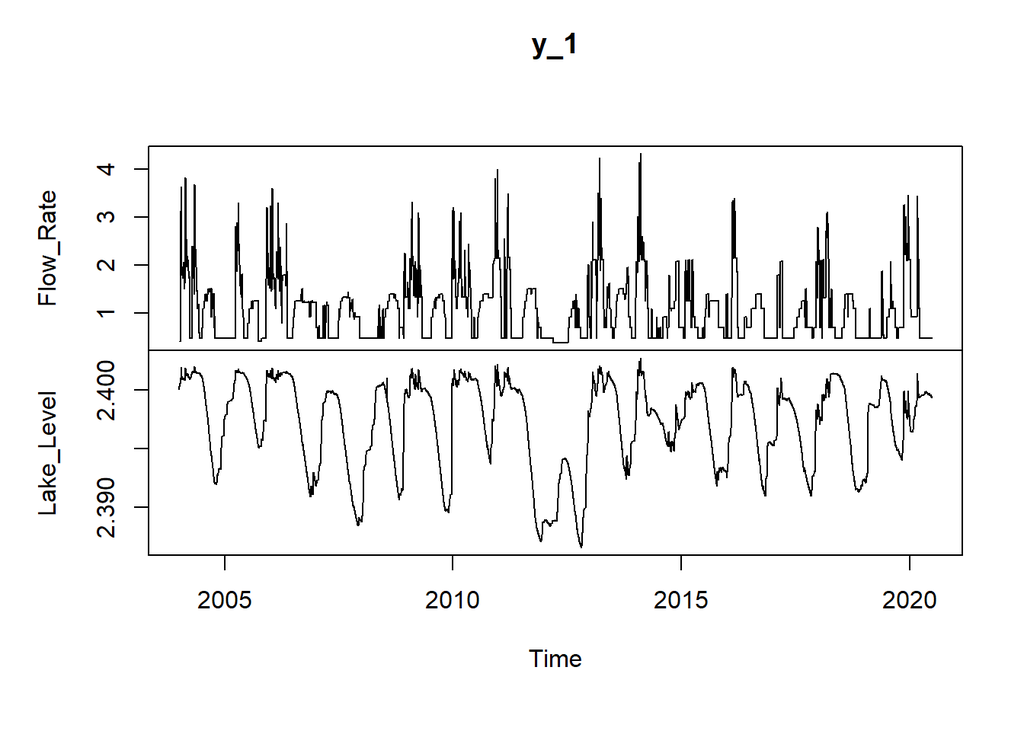

```r
plot(y_1)
```

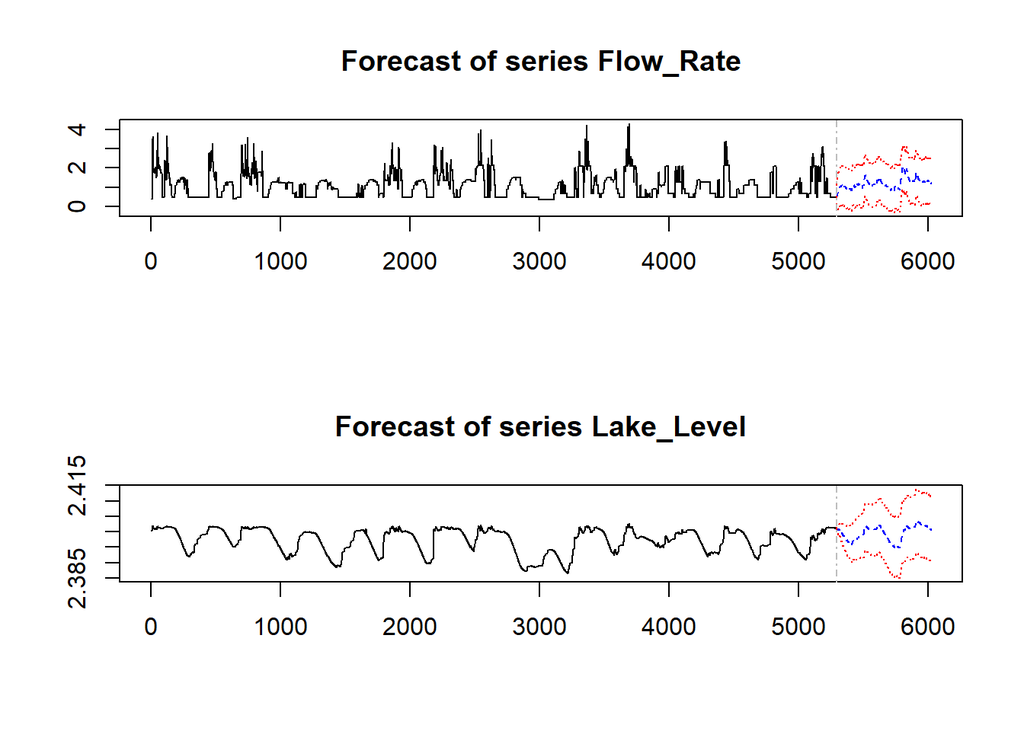

```r
plot(pred_y)
```

```r
cross_val_1 <- function(x, y, p) {
  max <- length(y[,1])-1
  border <- max-2*365
  pred_length <- 3
  errors_Flow=0
  errors_Level=0
  measures = 0
  while (border+pred_length <= max) {
    train_y <- y[2:border,]
    train_x <- x[2:border,]
    test_y <- y[(border+1):(border+pred_length),]
    test_x <- x[(border+1):(border+pred_length),]
    test_Model <- VAR(train_y, p = p, type = "const",  exogen = train_x)
    pred_y <- predict(test_Model, n.ahead = pred_length, dumvar=test_x, ci=0.95)
    check<-pred_y$fcst$Flow_Rate
    errors_Flow <- sum((check[,1]-test_y[,1])^2)+errors_Flow
    check<-pred_y$fcst$Lake_Level
    errors_Level <- sum((check[,1]-test_y[,2])^2)+errors_Level
    measures=measures + 3
    border=border+pred_length
  }
  RMSE_Flow = sqrt(errors_Flow/measures)
  RMSE_Level = sqrt(errors_Level/measures)
  c(RMSE_Flow,RMSE_Level)
}
```

```r
p=6
cross_val_1(x_1,y_1,p)
```

```
## [1] 0.1975833016 0.0002575874
```

So let’s try lag of 2 day.

```r
y_2 <- cbind(ts_Flow_Rate, ts_Lake_Level)
colnames(y_2)<-cbind("Flow_Rate", "Lake_Level")

x_2 <- cbind(shift(ts_Rainfall_Cavallina, n=2L), shift(ts_Rainfall_Le_Croci, n=2L), shift(ts_Rainfall_Mangona, n=2L), shift(ts_Rainfall_S_Agata, n=2L), shift(ts_Rainfall_S_Piero, n=2L), shift(ts_Temperature_Le_Croci, n=2L))
colnames(x_2)<-cbind("Rainfall_Cavallina", "Rainfall_Le_Croci", "Rainfall_Mangona", "Rainfall_S_Agata", "Rainfall_S_Piero", "Temperature_Le_Croci")

lagselect <- VARselect(y=y_2, type = "const", exogen = x_2)
lagselect$selection
```

```
## AIC(n)  HQ(n)  SC(n) FPE(n)
##      5      4      3      5
```

Now p is 5. Let’s try to predict values.

```r
train_y <- y_2[3:(border-2),]
train_x <- x_2[3:(border-2),]
test_y <- y_2[(border-1):6023,]
test_x <- x_2[(border-1):6023,]
```

```r
Model3 <- VAR(train_y, p = 5, type = "const",  exogen = train_x)
summary(Model3)
```

```
##
## VAR Estimation Results:
## =========================
## Endogenous variables: Flow_Rate, Lake_Level
## Deterministic variables: const
## Sample size: 5286
## Log Likelihood: 41063.249
## Roots of the characteristic polynomial:
## 0.998 0.9582 0.5731 0.5042 0.5042 0.3908 0.3908 0.2972 0.2972 0.2621
## Call:
## VAR(y = train_y, p = 5, type = "const", exogen = train_x)
##
##
## Estimation results for equation Flow_Rate:
## ==========================================
## Flow_Rate = Flow_Rate.l1 + Lake_Level.l1 + Flow_Rate.l2 + Lake_Level.l2 + Flow_Rate.l3 + Lake_Level.l3 + Flow_Rate.l4 + Lake_Level.l4 + Flow_Rate.l5 + Lake_Level.l5 + const + Rainfall_Cavallina + Rainfall_Le_Croci + Rainfall_Mangona + Rainfall_S_Agata + Rainfall_S_Piero + Temperature_Le_Croci
##
##                        Estimate Std. Error t value Pr(>|t|)
## Flow_Rate.l1          1.084e+00  1.427e-02  75.961  < 2e-16 ***
## Lake_Level.l1         7.623e+01  1.867e+01   4.083 4.52e-05 ***
## Flow_Rate.l2         -2.343e-01  2.112e-02 -11.091  < 2e-16 ***
## Lake_Level.l2        -2.607e+01  2.766e+01  -0.943 0.345973
## Flow_Rate.l3          6.879e-02  2.131e-02   3.228 0.001255 **
## Lake_Level.l3        -3.343e+01  2.669e+01  -1.252 0.210470
## Flow_Rate.l4          7.305e-03  2.118e-02   0.345 0.730202
## Lake_Level.l4         9.598e+00  2.621e+01   0.366 0.714192
## Flow_Rate.l5          3.715e-02  1.454e-02   2.556 0.010626 *
## Lake_Level.l5        -2.412e+01  1.581e+01  -1.525 0.127214
## const                -5.229e+00  1.558e+00  -3.356 0.000798 ***
## Rainfall_Cavallina    3.168e-04  9.729e-04   0.326 0.744717
## Rainfall_Le_Croci    -1.577e-03  8.687e-04  -1.816 0.069465 .
## Rainfall_Mangona     -4.809e-04  6.195e-04  -0.776 0.437621
## Rainfall_S_Agata     -1.146e-03  8.451e-04  -1.356 0.175202
## Rainfall_S_Piero      3.668e-03  1.071e-03   3.425 0.000621 ***
## Temperature_Le_Croci  3.525e-04  3.741e-04   0.942 0.346022
## ---
## Signif. codes:  0 '***' 0.001 '**' 0.01 '*' 0.05 '.' 0.1 ' ' 1
##
##
## Residual standard error: 0.1709 on 5269 degrees of freedom
```

[output cut: 30 more lines]

```
## Residual standard error: 0.0001509 on 5269 degrees of freedom
## Multiple R-Squared: 0.9985,  Adjusted R-squared: 0.9985
## F-statistic: 2.224e+05 on 16 and 5269 DF,  p-value: < 2.2e-16
##
##
##
## Covariance matrix of residuals:
##            Flow_Rate Lake_Level
## Flow_Rate  2.920e-02  6.922e-06
## Lake_Level 6.922e-06  2.277e-08
##
## Correlation matrix of residuals:
##            Flow_Rate Lake_Level
## Flow_Rate     1.0000     0.2684
## Lake_Level    0.2684     1.0000
```

P-value, R-squared and F-static are good.

Let’s try to predict values.

```r
pred_y <- predict(Model3, n.ahead =2*365, dumvar=test_x, ci=0.95)
```

Visualize test data and prediction.

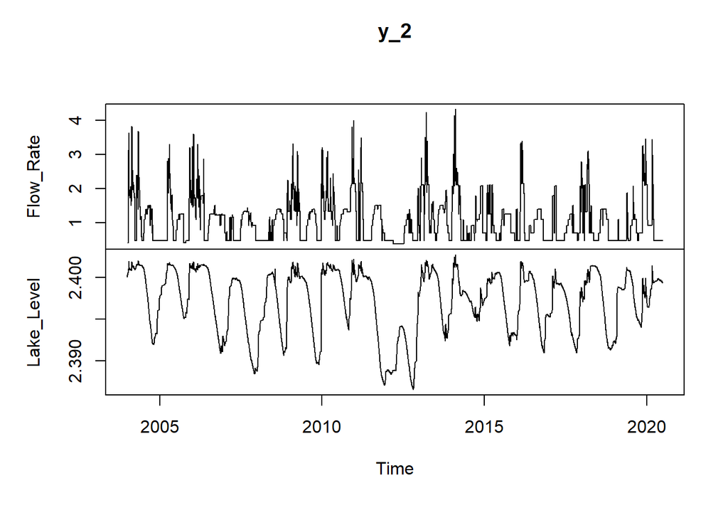

```r
plot(y_2)
```

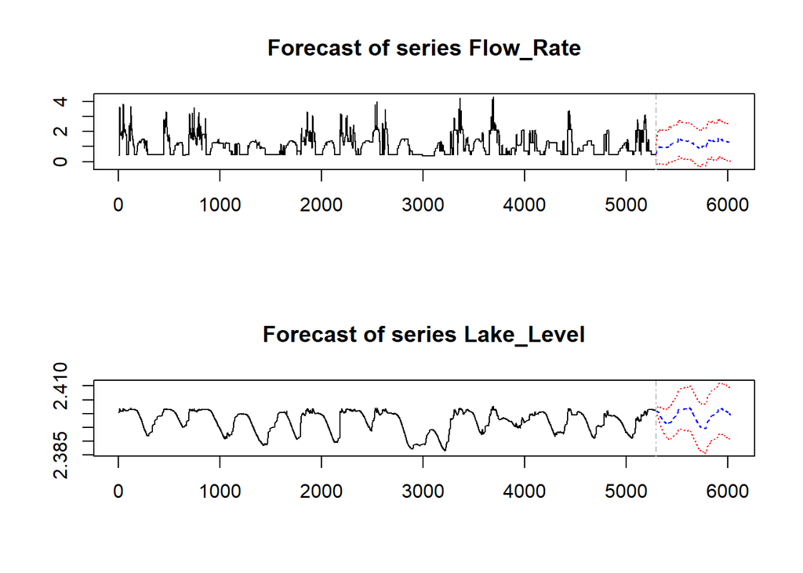

```r
plot(pred_y)
```

```r
cross_val_2 <- function(x, y, p) {
  max <- length(y[,1])-2
  border <- max-2*365
  pred_length <- 3
  errors_Flow=0
  errors_Level=0
  measures = 0
  while (border+pred_length <= max) {
    train_y <- y[3:border,]
    train_x <- x[3:border,]
    test_y <- y[(border+1):(border+pred_length),]
    test_x <- x[(border+1):(border+pred_length),]
    test_Model <- VAR(train_y, p = p, type = "const",  exogen = train_x)
    pred_y <- predict(test_Model, n.ahead = pred_length, dumvar=test_x, ci=0.95)
    check<-pred_y$fcst$Flow_Rate
    errors_Flow <- sum((check[,1]-test_y[,1])^2)+errors_Flow
    check<-pred_y$fcst$Lake_Level
    errors_Level <- sum((check[,1]-test_y[,2])^2)+errors_Level
    measures=measures + 3
    border=border+pred_length
  }
  RMSE_Flow = sqrt(errors_Flow/measures)
  RMSE_Level = sqrt(errors_Level/measures)
  c(RMSE_Flow,RMSE_Level)
}
```

```r
p=6
cross_val_2(x_2,y_2,p)
```

```
## [1] 0.2135376173 0.0002683524
```